# Module 1 - Intro to R

### Matrix

Matrices in R are basically multi-dimensional atomic vectors (A vector with dimensions). This means that all elements in a matrix must also be of the same data type. A matrix is instatiated via the `matrix()` function.

```r
m <- matrix(c(1:50), nrow=10,ncol=5)
m
```

```
##       [,1] [,2] [,3] [,4] [,5]
##  [1,]    1   11   21   31   41
##  [2,]    2   12   22   32   42
##  [3,]    3   13   23   33   43
##  [4,]    4   14   24   34   44
##  [5,]    5   15   25   35   45
##  [6,]    6   16   26   36   46
##  [7,]    7   17   27   37   47
##  [8,]    8   18   28   38   48
##  [9,]    9   19   29   39   49
## [10,]   10   20   30   40   50
```

```r
class(m)
```

```
## [1] "matrix" "array"
```

```r
typeof(m)
```

```
## [1] "integer"
```

You can get (and set) the dimensions of a matrix by using the `dim()` function

```r
dim(m) #Returns the current dimensions of m. Returns, in order, nRow and nCol
```

```
## [1] 10  5
```

```r
dim(m)<-c(2,25) # Change the dimensions of m to be 2 rows and 25 columns

dim(m)
```

```
## [1]  2 25
```

```r
head(m)
```

```
##      [,1] [,2] [,3] [,4] [,5] [,6] [,7] [,8] [,9] [,10] [,11] [,12] [,13] [,14]
## [1,]    1    3    5    7    9   11   13   15   17    19    21    23    25    27
## [2,]    2    4    6    8   10   12   14   16   18    20    22    24    26    28
##      [,15] [,16] [,17] [,18] [,19] [,20] [,21] [,22] [,23] [,24] [,25]
## [1,]    29    31    33    35    37    39    41    43    45    47    49
## [2,]    30    32    34    36    38    40    42    44    46    48    50
```

### Lists

Lists are similar to vectors, but allow for different data types. The individual elements of a list can be any type of R object, including other lists. Lists are created with the `list()` function.

```r
x <- list(3.1415, "neuron", 18L, FALSE)
x
```

```
## [[1]]
## [1] 3.1415
##
## [[2]]
## [1] "neuron"
##
## [[3]]
## [1] 18
##
## [[4]]
## [1] FALSE
```

Elements of a list an be indexed and retrieved using double square brackets.

```r
x[[1]] # retrieves the first element of the list x
```

```
## [1] 3.1415
```

```r
x[[1]] <- "4.0" # updates/sets the first element of the list x
```

The elements of a list can have unique names as well

```r
x <- list(pi=3.1415, celltype="neuron", myNum=18L, significant=FALSE)
x
```

```
## $pi
## [1] 3.1415
##
## $celltype
## [1] "neuron"
##
## $myNum
## [1] 18
##
## $significant
## [1] FALSE
```

```r
x['celltype']
```

```
## $celltype
## [1] "neuron"
```

```r
names(x) # Get or set list names
```

```
## [1] "pi"          "celltype"    "myNum"       "significant"
```

### Data Frames

One of the more widely used data structures in R is the data frame. A data frame is a collection of lists of the same length, and is the data structure of choice for tabular data. Columns in a data frame can contain different data types although each column must be an atomic vector (e.g. One column can be numeric, and the other can contain characters).

Data frames are created using the `data.frame()` function:

```r
genes <- data.frame(
  name=c("Asl","Apod","Cyp2d22","Klk6","Fcrls"),
  EntrezID=c(109900,11815,56448,19144,80891),
  chrom=c("chr5","chr16","chr15","chr7","chr3"),
  start=c(130011258,31297341,82259593,43825395,87250758)
)

genes
```

| name | EntrezID | chrom | start |
| --- | --- | --- | --- |
| Asl | 109900 | chr5 | 130011258 |
| Apod | 11815 | chr16 | 31297341 |
| Cyp2d22 | 56448 | chr15 | 82259593 |
| Klk6 | 19144 | chr7 | 43825395 |
| Fcrls | 80891 | chr3 | 87250758 |

```r
class(genes)
```

```
## [1] "data.frame"
```

```r
str(genes)
```

```
## 'data.frame':    5 obs. of  4 variables:
##  $ name    : chr  "Asl" "Apod" "Cyp2d22" "Klk6" ...
##  $ EntrezID: num  109900 11815 56448 19144 80891
##  $ chrom   : chr  "chr5" "chr16" "chr15" "chr7" ...
##  $ start   : num  1.30e+08 3.13e+07 8.23e+07 4.38e+07 8.73e+07
```

Individual columns of a data frame can be returned as a vector by using the `$` as so:

```r
genes$chrom
```

```
## [1] "chr5"  "chr16" "chr15" "chr7"  "chr3"
```

```r
genes$name
```

```
## [1] "Asl"     "Apod"    "Cyp2d22" "Klk6"    "Fcrls"
```

Matrices and dataframes can also be sliced using the square bracket nomenclature. Since these structures are more than one dimension, a comma is used to indicate which dimension is being sliced (first rows, then columns)

```r
genes[1:3,] #returns the first three rows of genes
```

|  | name | EntrezID | chrom | start |
| --- | --- | --- | --- | --- |
| 1 | Asl | 109900 | chr5 | 130011258 |
| 2 | Apod | 11815 | chr16 | 31297341 |
| 3 | Cyp2d22 | 56448 | chr15 | 82259593 |

```r
genes[,1:2] #returns the firwt two columns of genes
```

| name | EntrezID |
| --- | --- |
| Asl | 109900 |
| Apod | 11815 |
| Cyp2d22 | 56448 |
| Klk6 | 19144 |
| Fcrls | 80891 |

```r
genes[1:3,c("name","chrom")] # Column names can also be sliced/selected by name
```

|  | name | chrom |
| --- | --- | --- |
| 1 | Asl | chr5 |
| 2 | Apod | chr16 |
| 3 | Cyp2d22 | chr15 |

## Control Flow

Control flow is how you direct the computer to execute your code. This often involves making choices based on specific criteria (as in an if statement), or executing a code block repeatedly by iterating over a data structure such as a vector or list (for example in a for loop or apply() statement).

### if[else] and choice()

The overall structure of an if statement in R is:

```
if (condition) {
  true_action
}

if (condition) {
  true_action
} else {
  false_action
}
```

If the supplied `condition` statement evaluates to TRUE, then the `true_action` chunk (defined with `{}` is evaluated. If `condition` is `FALSE` then the optional `false_action` is run instead.

In practice, this looks something like:

```r
x<-40
if (x %% 2 == 0) {
  print("even")
} else {
  print("odd")
}
```

```
## [1] "even"
```

*Note the use of the double equals `==` ‘comparison’ operator. Remember that the single equals can be used as an assignment operator in R.*

`if` however, only works on a single logical comparison at a time. R has a special form of if that can operate over a vector to test multiple conditions at once called `ifelse()`

```r
x <-1:20

ifelse(x %% 2 == 0, "even", "odd")
```

```
##  [1] "odd"  "even" "odd"  "even" "odd"  "even" "odd"  "even" "odd"  "even"
## [11] "odd"  "even" "odd"  "even" "odd"  "even" "odd"  "even" "odd"  "even"
```

### Looping/Iteration

Loops are used to iterate over items in a vector or list.

#### For loops

`for` loops perform the tasks defined in a code chunk for each item of a list or vector. The syntax of a for loop will have the following structure:

```
for (<variable> in <vector>) {
  <code chunk to execute>
}
```

In the following case, the loop is iterating over a vector of numbers from 1 to 10, and in each instance of the loop, assigning the value to a variable `i`.

```r
for (i in c(1:10)) {
  print(i)
}
```

```
## [1] 1
## [1] 2
## [1] 3
## [1] 4
## [1] 5
## [1] 6
## [1] 7
## [1] 8
## [1] 9
## [1] 10
```

# Summary Stats and basic visualization

To briefly show you around some basic summary statistics and base graphics plots in R, lets first import a commonly used dataset. The `iris` dataset contains multiple parameter measurements (columns) for individual flowers (rows).

```r
data(iris) # loads a pre-stored data frame called 'iris'

head(iris)
```

|  | Sepal.Length | Sepal.Width | Petal.Length | Petal.Width | Species |
| --- | --- | --- | --- | --- | --- |
| 1 | 5.1 | 3.5 | 1.4 | 0.2 | setosa |
| 2 | 4.9 | 3.0 | 1.4 | 0.2 | setosa |
| 3 | 4.7 | 3.2 | 1.3 | 0.2 | setosa |
| 4 | 4.6 | 3.1 | 1.5 | 0.2 | setosa |
| 5 | 5.0 | 3.6 | 1.4 | 0.2 | setosa |
| 6 | 5.4 | 3.9 | 1.7 | 0.4 | setosa |

```r
dim(iris)
```

```
## [1] 150   5
```

Since each row is an observation here, and each column is a parameter, we can use these tabular data to explore different Lets start by looking at some summary statistics for each column of this data frame

```r
summary(iris)
```

```
##   Sepal.Length    Sepal.Width     Petal.Length    Petal.Width
##  Min.   :4.300   Min.   :2.000   Min.   :1.000   Min.   :0.100
##  1st Qu.:5.100   1st Qu.:2.800   1st Qu.:1.600   1st Qu.:0.300
##  Median :5.800   Median :3.000   Median :4.350   Median :1.300
##  Mean   :5.843   Mean   :3.057   Mean   :3.758   Mean   :1.199
##  3rd Qu.:6.400   3rd Qu.:3.300   3rd Qu.:5.100   3rd Qu.:1.800
##  Max.   :7.900   Max.   :4.400   Max.   :6.900   Max.   :2.500
##        Species
##  setosa    :50
##  versicolor:50
##  virginica :50
##
##
##
```

Lets plot a histogram of some of the parameters

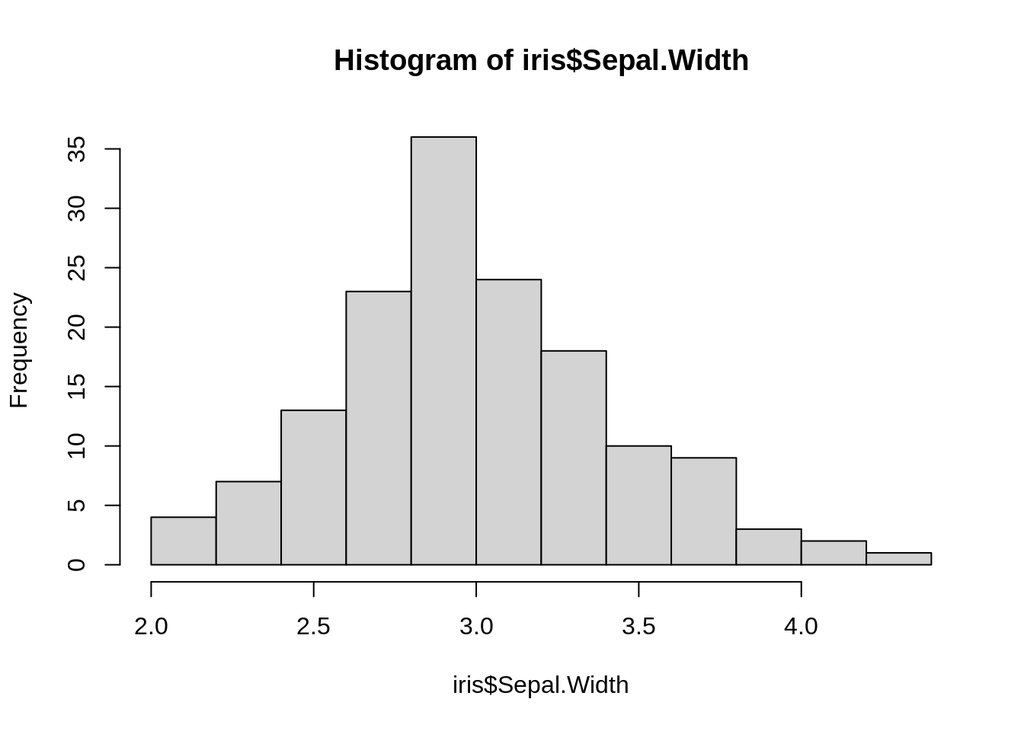

```r
hist(iris$Sepal.Width)
```

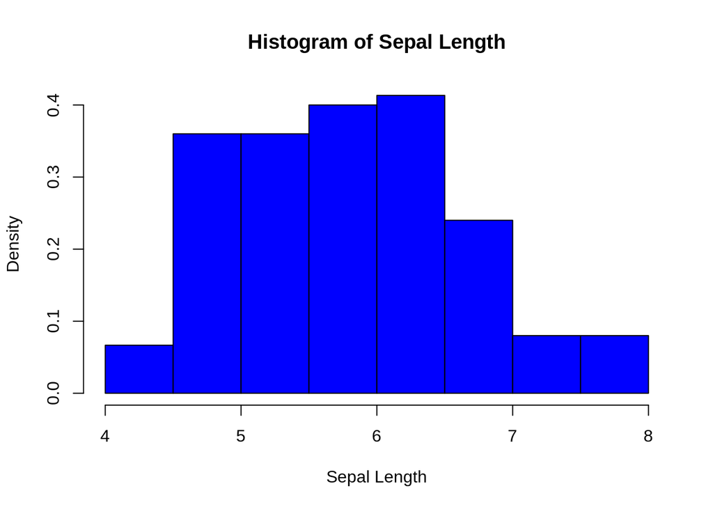

```r
hist(iris$Sepal.Length, main="Histogram of Sepal Length", xlab="Sepal Length", col="blue", freq=FALSE)
```

We can plot pairwise variables on a scatter plot using `plot(x,y)` where `x` and `y` are the variables we are interested in

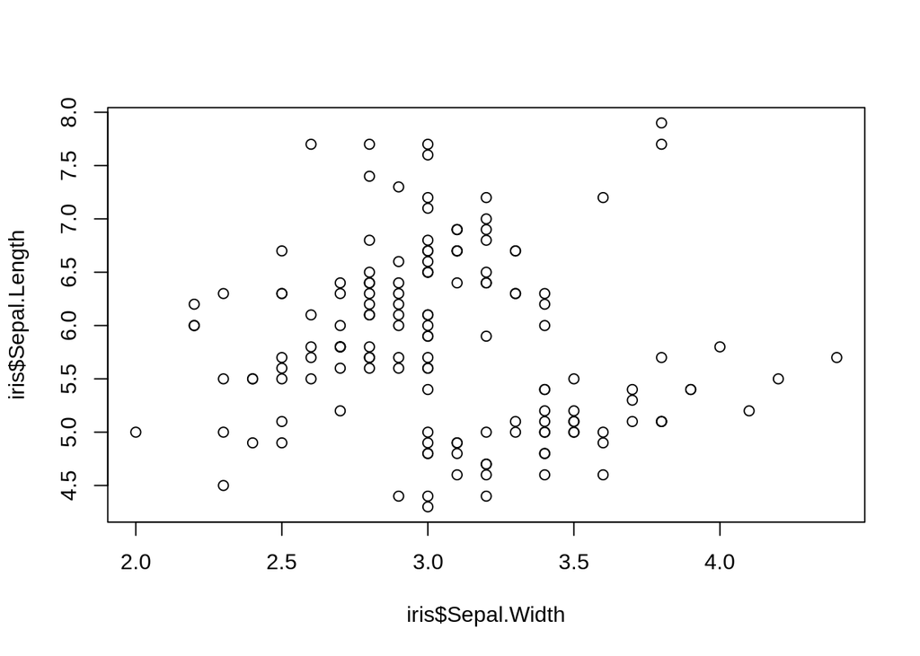

```r
plot(iris$Sepal.Width, iris$Sepal.Length)
```

We can color the points by species by passing the species name to the `col` argument

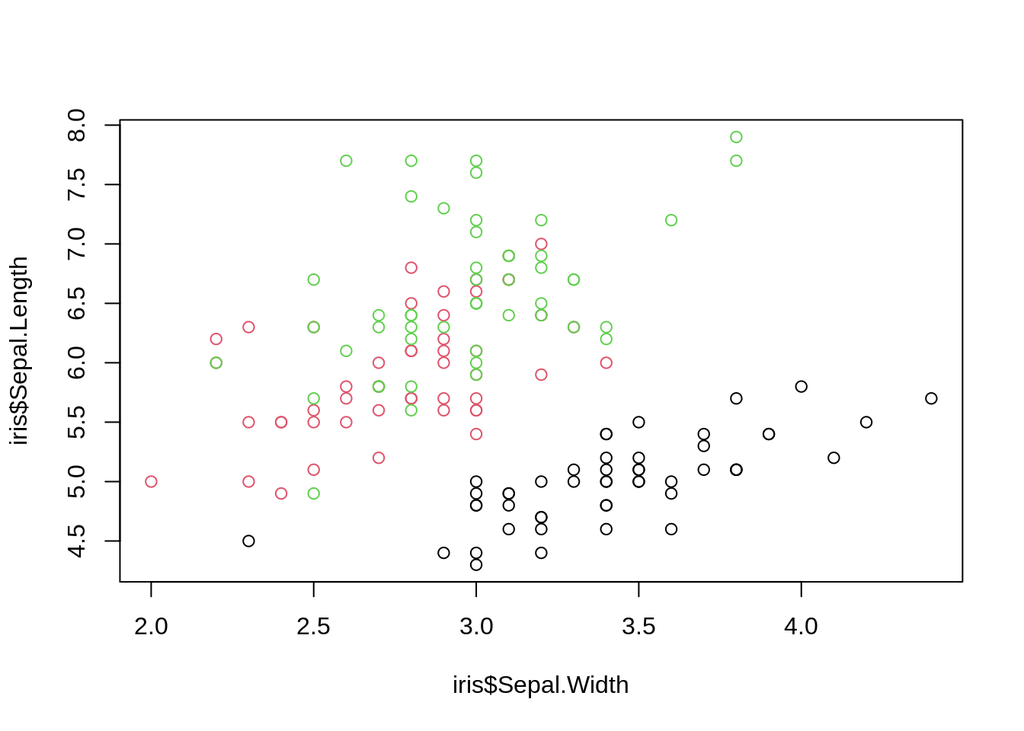

```r
plot(iris$Sepal.Width, iris$Sepal.Length, col=iris$Species)
```

## Final Notes

- This overview only serves to introduce you to R. It is by no means comprehensive. As with much of this course, you will need to spend a decent amount of time on self-guided tours and tutorials. Please spend some time this week familiarizing yourself with R, R studio. There are a number of online tutorials that can be found online.
- As the course progresses, we will learn to use different packages to create graphical representations of our data. One of the most widely used packages in R for visualization is [ggplot2](https://ggplot2.tidyverse.org/) which defines a ‘grammar of graphics’. While this might take some time to familiarize yourself with, it is a useful framework to learn to make better visualizations. [Cheat Sheet](https://raw.githubusercontent.com/rstudio/cheatsheets/main/data-visualization.pdf)
- If you have any questions about the interactive notebooks, how to navigate using R/RStudio, or how to setup your compute environment at this point, please reach out to us through canvas, email, or the course slack workgroup. We will also be happy to answer and address your questions on the first day of class this friday.